# Exercise 1

# Exercise introduction

This is Exercise 1 in Part 4 of the course.

The purpose of the exercise is to cover ANOVA and Kruskal Wallis

## Part 1: Different costs between different housing options in Stockholm

### Step 1: Import data

```r
housing <- readr::read_tsv('../p02_inputs/Cost_month.txt') %>% tibble()
```

### Step 2: One-way ANOVA

```r
library(mvtnorm, pos=70)
library(survival, pos=70)
library(TH.data, pos=70)
library(multcomp, pos=70)
```

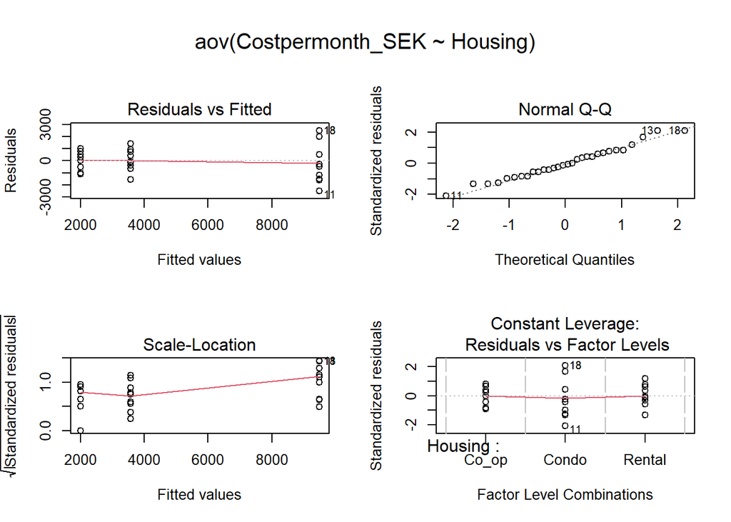

```r
library(abind, pos=74)

housing %<>%
    mutate(Housing = as.factor(Housing))

costModel <- aov(Costpermonth_SEK ~ Housing, data=housing)

oldpar <- par(oma=c(0,0,3,0), mfrow=c(2,2))
plot(costModel)
```

```r
par(oldpar)
```

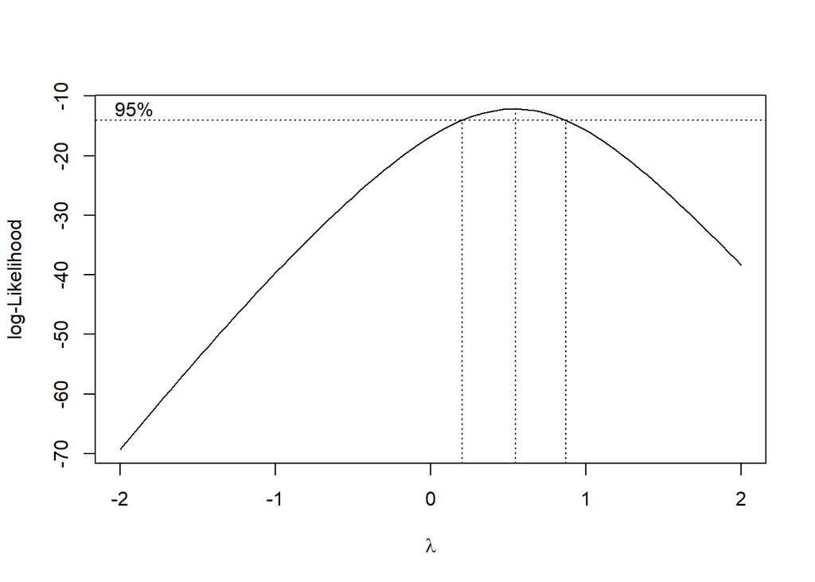

```r
library(MASS)
bc <- boxcox(Costpermonth_SEK ~ Housing, data = housing)
```

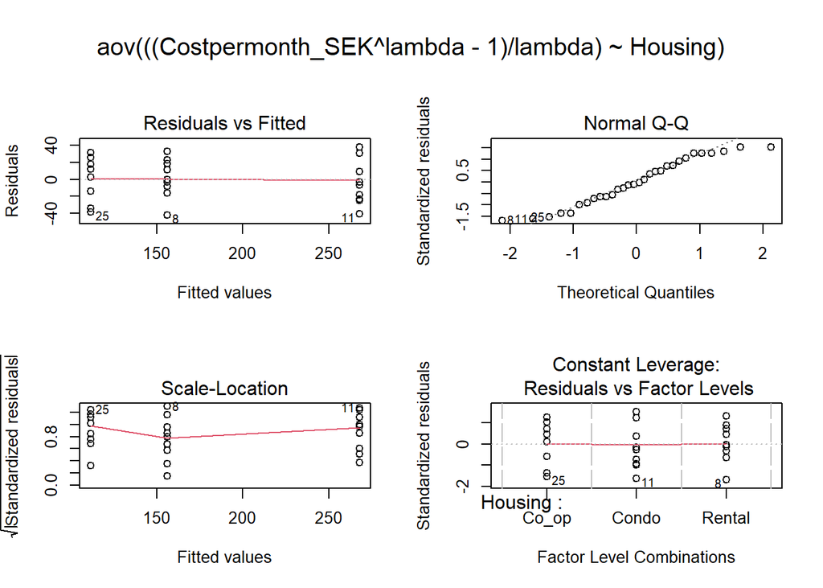

```r
lambda <- bc$x[which.max(bc$y)]
bcCostModel <- aov(((Costpermonth_SEK ^ lambda - 1) / lambda) ~ Housing, data = housing)
oldpar <- par(oma=c(0,0,3,0), mfrow=c(2,2))
plot(bcCostModel)
```

```r
par(oldpar)
```

```r
summary(bcCostModel)
```

```
##             Df Sum Sq Mean Sq F value            Pr(>F)
## Housing      2 130016   65008   94.72 0.000000000000626 ***
## Residuals   27  18531     686
## ---
## Signif. codes:  0 '***' 0.001 '**' 0.01 '*' 0.05 '.' 0.1 ' ' 1
```

```r
summary(costModel)
```

```
##             Df    Sum Sq   Mean Sq F value            Pr(>F)
## Housing      2 312038000 156019000   97.53 0.000000000000442 ***
## Residuals   27  43190000   1599630
## ---
## Signif. codes:  0 '***' 0.001 '**' 0.01 '*' 0.05 '.' 0.1 ' ' 1
```

```r
library(RcmdrMisc)
with(housing, numSummary(Costpermonth_SEK, groups=Housing, statistics=c("mean", "sd")))
```

```
##        mean        sd data:n
## Co_op  2000  845.9052     10
## Condo  9490 1813.1924     10
## Rental 3570  892.0015     10
```

```
##
##   Simultaneous Tests for General Linear Hypotheses
##
## Multiple Comparisons of Means: Tukey Contrasts
##
##
## Fit: aov(formula = ((Costpermonth_SEK^lambda - 1)/lambda) ~ Housing,
##     data = housing)
##
## Linear Hypotheses:
##                     Estimate Std. Error t value Pr(>|t|)
## Condo - Co_op == 0    156.47      11.72  13.355 < 0.0001 ***
## Rental - Co_op == 0    44.47      11.72   3.796  0.00203 **
## Rental - Condo == 0  -112.00      11.72  -9.560 < 0.0001 ***
## ---
## Signif. codes:  0 '***' 0.001 '**' 0.01 '*' 0.05 '.' 0.1 ' ' 1
## (Adjusted p values reported -- single-step method)
##
##
##   Simultaneous Confidence Intervals
##
## Multiple Comparisons of Means: Tukey Contrasts
##
##
## Fit: aov(formula = ((Costpermonth_SEK^lambda - 1)/lambda) ~ Housing,
##     data = housing)
##
## Quantile = 2.4807
## 95% family-wise confidence level
##
##
## Linear Hypotheses:
##                     Estimate  lwr       upr
## Condo - Co_op == 0   156.4706  127.4063  185.5349
## Rental - Co_op == 0   44.4699   15.4056   73.5342
## Rental - Condo == 0 -112.0007 -141.0650  -82.9364
##
##  Co_op  Condo Rental
##    "a"    "c"    "b"
```

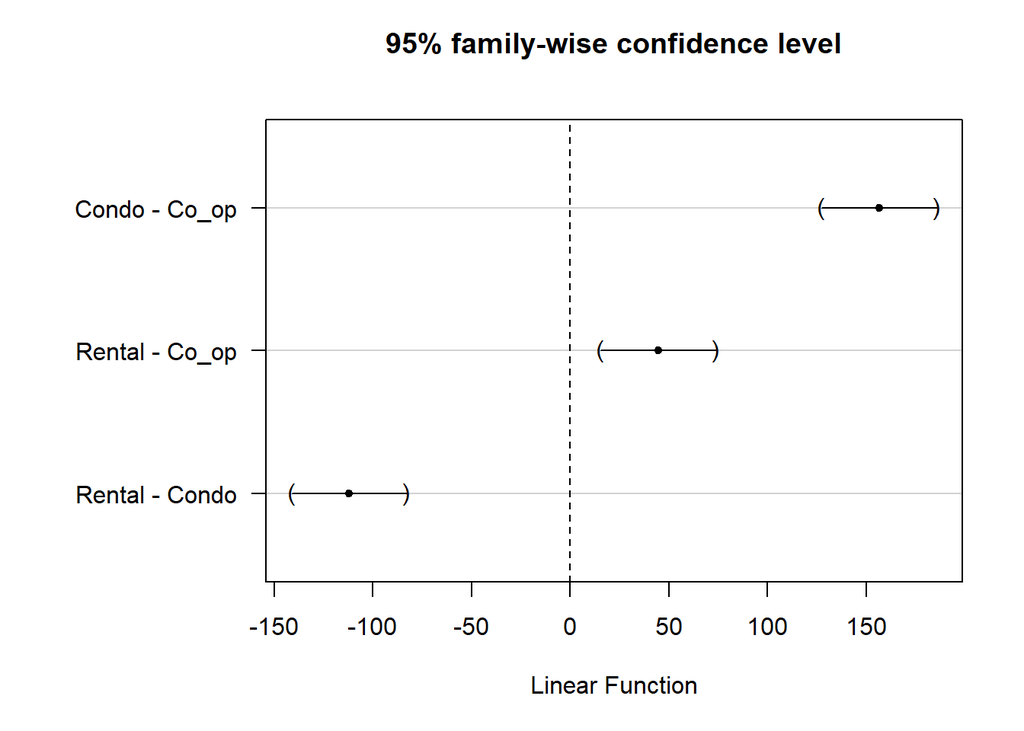

```r
local({
  .Pairs <- glht(bcCostModel, linfct = mcp(Housing = "Tukey"))
  print(summary(.Pairs)) # pairwise tests
  print(confint(.Pairs, level=0.95)) # confidence intervals
  print(cld(.Pairs, level=0.05)) # compact letter display
  old.oma <- par(oma=c(0, 5, 0, 0))
  plot(confint(.Pairs))
  par(old.oma)
})
```

```
##
##   Simultaneous Tests for General Linear Hypotheses
##
## Multiple Comparisons of Means: Tukey Contrasts
##
##
## Fit: aov(formula = Costpermonth_SEK ~ Housing, data = housing)
##
## Linear Hypotheses:
##                     Estimate Std. Error t value Pr(>|t|)
## Condo - Co_op == 0    7490.0      565.6  13.242   <0.001 ***
## Rental - Co_op == 0   1570.0      565.6   2.776   0.0258 *
## Rental - Condo == 0  -5920.0      565.6 -10.466   <0.001 ***
## ---
## Signif. codes:  0 '***' 0.001 '**' 0.01 '*' 0.05 '.' 0.1 ' ' 1
## (Adjusted p values reported -- single-step method)
##
##
##   Simultaneous Confidence Intervals
##
## Multiple Comparisons of Means: Tukey Contrasts
##
##
## Fit: aov(formula = Costpermonth_SEK ~ Housing, data = housing)
##
## Quantile = 2.4816
## 95% family-wise confidence level
##
##
## Linear Hypotheses:
##                     Estimate   lwr        upr
## Condo - Co_op == 0   7490.0000  6086.3777  8893.6223
## Rental - Co_op == 0  1570.0000   166.3777  2973.6223
## Rental - Condo == 0 -5920.0000 -7323.6223 -4516.3777
##
##  Co_op  Condo Rental
##    "a"    "c"    "b"
```

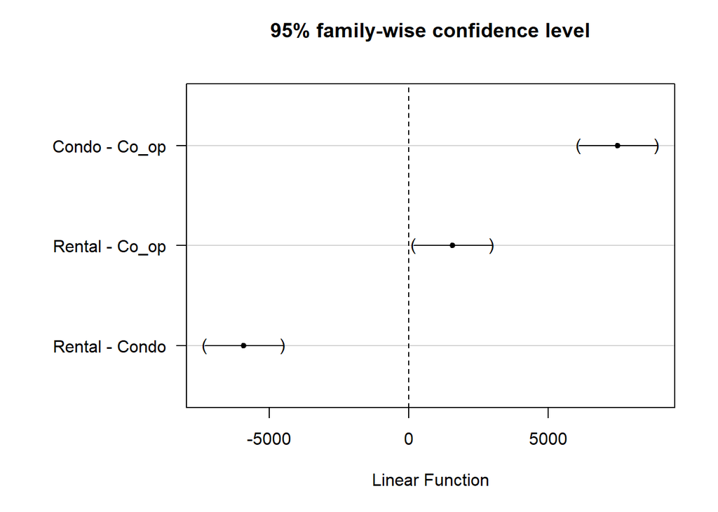

```r
local({
  .Pairs <- glht(costModel, linfct = mcp(Housing = "Tukey"))
  print(summary(.Pairs)) # pairwise tests
  print(confint(.Pairs, level=0.95)) # confidence intervals
  print(cld(.Pairs, level=0.05)) # compact letter display
  old.oma <- par(oma=c(0, 5, 0, 0))
  plot(confint(.Pairs))
  par(old.oma)
})
```

## Part 2: Different stress factors effects on heart rate

I did this exercise for another course, so am skipping it here.

## Part 3: Chlorophyll-α concentrations (μg/l) in the different basins of the Baltic Sea

```r
(chlor <- readr::read_tsv('../p02_inputs/Chla.txt') %>% tibble())
```

```
## # A tibble: 13,356 x 4
##    Parameter     Chlorophyll_a Basin  LARGE_basin
##    <chr>         <chr>         <chr>  <chr>
##  1 Chlorophyll_a 0,20          Arkona Arkona
##  2 Chlorophyll_a 0,25          Arkona Arkona
##  3 Chlorophyll_a 0,30          Arkona Arkona
##  4 Chlorophyll_a 0,30          Arkona Arkona
##  5 Chlorophyll_a 0,30          Arkona Arkona
##  6 Chlorophyll_a 0,30          Arkona Arkona
##  7 Chlorophyll_a 0,30          Arkona Arkona
##  8 Chlorophyll_a 0,30          Arkona Arkona
##  9 Chlorophyll_a 0,30          Arkona Arkona
## 10 Chlorophyll_a 0,30          Arkona Arkona
## # ... with 13,346 more rows
```

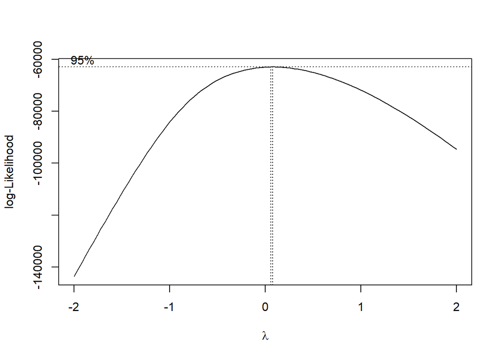

```r
chlor %<>%
    mutate(Basin = as.factor(Basin)
           , LARGE_basin = as.factor(LARGE_basin)
           , Chlorophyll_a = as.numeric(str_replace(Chlorophyll_a, ',', '.')))

bcChlor <- boxcox(Chlorophyll_a ~ LARGE_basin, data = chlor)
```

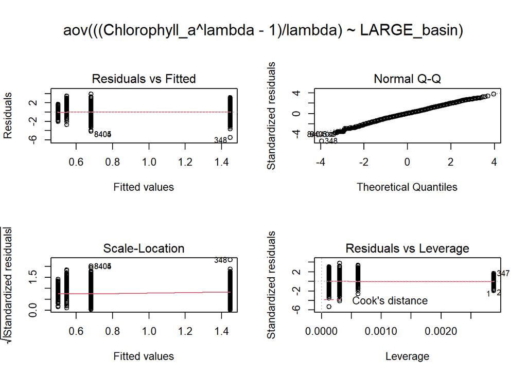

```r
lambda <- bc$x[which.max(bcChlor$y)]
bcChlorAov <- aov(((Chlorophyll_a ^ lambda - 1) / lambda) ~ LARGE_basin, data = chlor)
oldpar <- par(oma=c(0,0,3,0), mfrow=c(2,2))
plot(bcChlorAov)
```

```r
par(oldpar)
```

```r
summary(bcChlorAov)
```

```
##                Df Sum Sq Mean Sq F value              Pr(>F)
## LARGE_basin     3   2160   719.9   680.6 <0.0000000000000002 ***
## Residuals   13352  14124     1.1
## ---
## Signif. codes:  0 '***' 0.001 '**' 0.01 '*' 0.05 '.' 0.1 ' ' 1
```

```r
with(chlor, numSummary(Chlorophyll_a, groups=LARGE_basin, statistics=c("mean", "sd")))
```

```
##                  mean       sd data:n
## Arkona       2.020115 1.395582    347
## BalticProper 6.140911 6.544096   8056
## Bothnian     2.751541 2.680360   3323
## Western      2.638982 3.243289   1630
```

```
##
##   Simultaneous Tests for General Linear Hypotheses
##
## Multiple Comparisons of Means: Tukey Contrasts
##
##
## Fit: aov(formula = ((Chlorophyll_a^lambda - 1)/lambda) ~ LARGE_basin,
##     data = chlor)
##
## Linear Hypotheses:
##                              Estimate Std. Error t value Pr(>|t|)
## BalticProper - Arkona == 0    0.94589    0.05639  16.774  < 0.001 ***
## Bothnian - Arkona == 0        0.18138    0.05802   3.126  0.00848 **
## Western - Arkona == 0         0.04894    0.06081   0.805  0.83974
## Bothnian - BalticProper == 0 -0.76451    0.02120 -36.054  < 0.001 ***
## Western - BalticProper == 0  -0.89695    0.02793 -32.110  < 0.001 ***
## Western - Bothnian == 0      -0.13244    0.03110  -4.258  < 0.001 ***
## ---
## Signif. codes:  0 '***' 0.001 '**' 0.01 '*' 0.05 '.' 0.1 ' ' 1
## (Adjusted p values reported -- single-step method)
##
##
##   Simultaneous Confidence Intervals
##
## Multiple Comparisons of Means: Tukey Contrasts
##
##
## Fit: aov(formula = ((Chlorophyll_a^lambda - 1)/lambda) ~ LARGE_basin,
##     data = chlor)
##
## Quantile = 2.5232
## 95% family-wise confidence level
##
##
## Linear Hypotheses:
##                              Estimate lwr      upr
## BalticProper - Arkona == 0    0.94589  0.80361  1.08817
## Bothnian - Arkona == 0        0.18138  0.03497  0.32779
## Western - Arkona == 0         0.04894 -0.10449  0.20237
## Bothnian - BalticProper == 0 -0.76451 -0.81802 -0.71101
## Western - BalticProper == 0  -0.89695 -0.96743 -0.82647
## Western - Bothnian == 0      -0.13244 -0.21091 -0.05396
##
##       Arkona BalticProper     Bothnian      Western
##          "a"          "c"          "b"          "a"
```

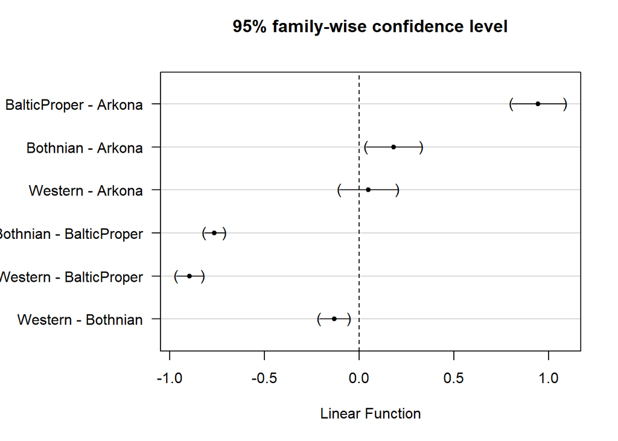

```r
local({
  .Pairs <- glht(bcChlorAov, linfct = mcp(LARGE_basin = "Tukey"))
  print(summary(.Pairs)) # pairwise tests
  print(confint(.Pairs, level=0.95)) # confidence intervals
  print(cld(.Pairs, level=0.05)) # compact letter display
  old.oma <- par(oma=c(0, 5, 0, 0))
  plot(confint(.Pairs))
  par(old.oma)
})
```

Using Kruskal-Wallis as an alternative.

```r
# install.packages('pgirmess')
library(pgirmess)
library(PMCMRplus)
attach(chlor)
pgirmess::kruskalmc(Chlorophyll_a, LARGE_basin, probs = 0.05, cont=NULL)#resp=your response variable, cat= is your categorical varible
```

```
## Multiple comparison test after Kruskal-Wallis
## p.value: 0.05
## Comparisons
##                         obs.dif critical.dif difference
## Arkona-BalticProper   3607.3275     557.7145       TRUE
## Arkona-Bothnian       1024.9310     573.8816       TRUE
## Arkona-Western         317.2095     601.4008      FALSE
## BalticProper-Bothnian 2582.3964     209.7231       TRUE
## BalticProper-Western  3290.1179     276.2726       TRUE
## Bothnian-Western       707.7215     307.6057       TRUE
```

```r
kruskal_posthoc <- PMCMRplus::kwAllPairsNemenyiTest(x = Chlorophyll_a, g = LARGE_basin, dist = "Tukey")
summary(kruskal_posthoc)
```

```
##
##  Pairwise comparisons using Tukey-Kramer-Nemenyi all-pairs test with Tukey-Dist approximation
```

```
## data: Chlorophyll_a and LARGE_basin
```

```
## alternative hypothesis: two.sided
```

```
## P value adjustment method: single-step
```

```
## H0
```

```
##                              q value               Pr(>|q|)
## BalticProper - Arkona == 0    24.133 < 0.000000000000000222 ***
## Bothnian - Arkona == 0         6.664        0.0000145906484 ***
## Western - Arkona == 0          1.968                0.50462
## Bothnian - BalticProper == 0  45.942 < 0.000000000000000222 ***
## Western - BalticProper == 0   44.433 < 0.000000000000000222 ***
## Western - Bothnian == 0        8.584        0.0000000076718 ***
```

```
## Signif. codes: 0 '***' 0.001 '**' 0.01 '*' 0.05 '.' 0.1 ' ' 1
```

```r
detach(chlor)
```

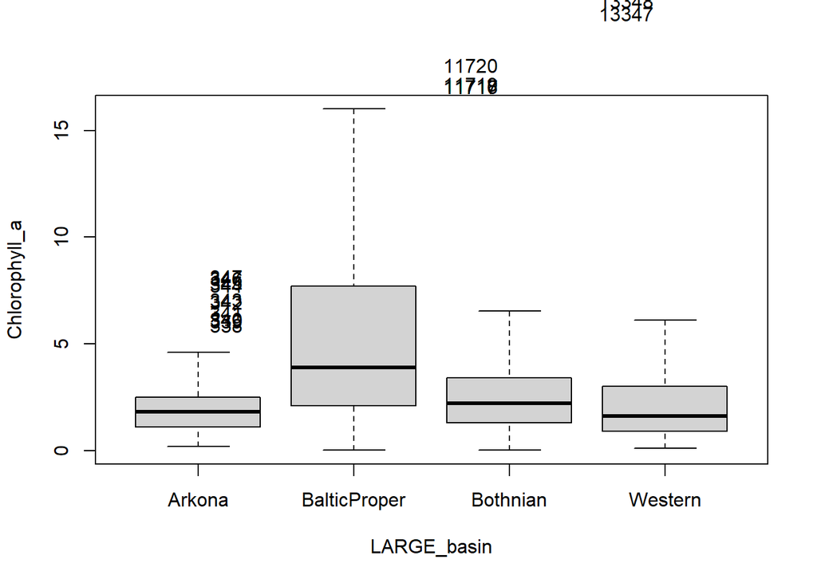

```
##  [1] "347"   "346"   "345"   "344"   "343"   "342"   "341"   "340"   "339"
## [10] "338"   "8403"  "8402"  "8401"  "8400"  "8399"  "8398"  "8397"  "8396"
## [19] "8395"  "8394"  "11726" "11725" "11724" "11723" "11722" "11721" "11720"
## [28] "11719" "11716" "11717" "13356" "13355" "13354" "13353" "13352" "13350"
## [37] "13351" "13349" "13348" "13347"
```

```r
Boxplot(Chlorophyll_a ~ LARGE_basin, data = chlor, id=list(method="y"), outline= FALSE)
```

# Key learnings

- Function `aov` and `lm` both take formula syntax, and both accept dependent variables expressed as complex expressions, permitting box-cox transformations. However, their output is slightly different in that a `lm` that uses an independent factor variable will by default split that variable into k-1 estimates where k is the number of factor levels, whereas `aov` retains it as a simple variable. This can be seen by the call of `summary(<model>)`
- The box-cox transformation is easy to implement, but does not necessarily result in lower p-values even if the model is a better overall fit.
- Can use either `pgirmess::kruskalmc` or `PMCMRpluss::kwAllPairsNemenyiTest` to do Kruskal-Wallis tests with pairwise post-hoc comparisons.

# Unresolved questions

- How to use `mcp` with alternatives other than ‘Tukey’? For example, if I wanted an ‘fdr’ post-hoc correction?
- Why does function `Boxplot` still include some labeled outliers if set `outline = FALSE`?